# FurkanGundogan_pro

## Furkan Gündoğan 1821221005

```python
import pandas as pd
import numpy as np
import matplotlib.pyplot as plt
import seaborn as sns
```

```python
imdb = pd.read_csv('IMDB-Movie-Data.csv')
```

```python
imdb.drop(labels=["Rank","Description","Actors"], axis=1,inplace=True)
```

Before start, I took off Rank, Description, Actors columns. Beacuse Rank is just index value which given by dataset-creator. Description and Actors are have long texts.

#### 1) Print the first 5 elements of your DataFrame using the command head(). How many features are there and what are their types (e.g., numeric, nominal)?

```
My dataset: IMDB's 1000 movies datas from 2006 to 2016.
My dataset has 9 features;
    Nominal features:
        Title: Title of Movie
        Genre: Genres of Movie
        Director: Director of Movie
    Numeric features:
        Year: Release Year of Movie
        Runtime: Total duration of Movie
        Rating: Average ratings of audiences
        Votes: Total vote count of audiences
        Revenue: Earned money from movie
        Metascore: Average ratings of film critics
```

```python
imdb.head()
```

|  | Title | Genre | Director | Year | Runtime | Rating | Votes | Revenue | Metascore |
| --- | --- | --- | --- | --- | --- | --- | --- | --- | --- |
| 0 | Guardians of the Galaxy | Action,Adventure,Sci-Fi | James Gunn | 2014 | 121 | 8.1 | 757074 | 333.13 | NaN |
| 1 | Prometheus | Adventure,Mystery,Sci-Fi | Ridley Scott | 2012 | 124 | 7.0 | 485820 | 126.46 | 65.0 |
| 2 | Split | Horror,Thriller | M. Night Shyamalan | 2016 | 117 | 7.3 | 157606 | 138.12 | 62.0 |
| 3 | Sing | Animation,Comedy,Family | Christophe Lourdelet | 2016 | 108 | 7.2 | 60545 | 270.32 | 59.0 |
| 4 | Suicide Squad | Action,Adventure,Fantasy | David Ayer | 2016 | 123 | 6.2 | 393727 | 325.02 | 40.0 |

#### 2) Compute and display summary statistics for each numeric feature available in the dataset. These must include the minimum value, maximum value, mean, range, standard deviation, variance, count, and 25:50:75% percentiles.

```python
# 2.a) Year
a = np.array(imdb.Year)
print("2.a) Year\n");
print("Sum: ",a.sum());
print("Max: ", a.max());print("Min: ",a.min());
print("Range: ",a.max()-a.min());
print("Mean ", a.mean());
print("Std: ",a.std());print("Variance: ",a.var());
print("Count: ",len(a));
print("\nPercentiles");
print("25%:",np.percentile(a,25));
print("50%:",np.percentile(a,50));
print("75%:",np.percentile(a,75));
```

```
2.a) Year

Sum:  2012783
Max:  2016
Min:  2006
Range:  10
Mean  2012.783
Std:  3.2043581260527043
Variance:  10.267911
Count:  1000

Percentiles
25%: 2010.0
50%: 2014.0
75%: 2016.0
```

```python
# 2.b) Runtime
b = np.array(imdb.Runtime)
print("2.b) Runtime\n");
print("Sum: ",b.sum());
print("Max: ", b.max());print("Min: ",b.min());
print("Range: ",b.max()-b.min());
print("Mean ", b.mean());
print("Std: ",b.std());print("Variance: ",b.var());
print("Count: ",len(b));
print("\nPercentiles");
print("25%:",np.percentile(b,25));
print("50%:",np.percentile(b,50));
print("75%:",np.percentile(b,75));
```

```
2.b) Runtime

Sum:  113172
Max:  191
Min:  66
Range:  125
Mean  113.172
Std:  18.80150036566231
Variance:  353.49641599999995
Count:  1000

Percentiles
25%: 100.0
50%: 111.0
75%: 123.0
```

```python
# 2.c) Rating
c = np.array(imdb.Rating)
print("2.c) Rating\n");
print("Sum: ",c.sum());
print("Max: ", c.max());print("Min: ",c.min());
print("Range: ",c.max()-c.min());
print("Mean ", c.mean());
print("Std: ",c.std());print("Variance: ",c.var());
print("Count: ",len(c));
print("\nPercentiles");
print("25%:",np.percentile(c,25));
print("50%:",np.percentile(c,50));
print("75%:",np.percentile(c,75));
```

```
2.c) Rating

Sum:  6723.2
Max:  9.0
Min:  1.9
Range:  7.1
Mean  6.723199999999999
Std:  0.9449559566455994
Variance:  0.8929417599999999
Count:  1000

Percentiles
25%: 6.2
50%: 6.8
75%: 7.4
```

```python
# 2.d) Votes
d = np.array(imdb.Votes)
print("2.d) Votes\n");
print("Sum: ",d.sum());
print("Max: ", d.max());print("Min: ",d.min());
print("Range: ",d.max()-d.min());
print("Mean ", d.mean());
print("Std: ",d.std());print("Variance: ",d.var());
print("Count: ",len(d));
print("\nPercentiles");
print("25%:",np.percentile(d,25));
print("50%:",np.percentile(d,50));
print("75%:",np.percentile(d,75));
```

```
2.d) Votes

Sum:  169808255
Max:  1791916
Min:  61
Range:  1791855
Mean  169808.255
Std:  188668.2425873257
Variance:  35595705760.989975
Count:  1000

Percentiles
25%: 36309.0
50%: 110799.0
75%: 239909.75
```

```python
# 2.e) Revenue (Million $)
e = np.array(imdb.Revenue)
print("2.e) Revenue (Million $)");
print("Calculations could not be performed because of missing values\n");
print("Sum: ",e.sum());
print("Max: ", e.max());print("Min: ",e.min());
print("Range: ",e.max()-e.min());
print("Mean ", e.mean());
print("Std: ",e.std());print("Variance: ",e.var());
print("Count: ",len(e));
print("\nPercentiles");
print("25%:",np.percentile(e,25));
print("50%:",np.percentile(e,50));
print("75%:",np.percentile(e,75));
```

```
2.e) Revenue (Million $)
Calculations could not be performed because of missing values

Sum:  nan
Max:  nan
Min:  nan
Range:  nan
Mean  nan
Std:  nan
Variance:  nan
Count:  1000

Percentiles
25%: nan
50%: nan
75%: nan
```

```python
# 2.f) Metascore
f = np.array(imdb.Metascore)
print("2.f) Metascore");
print("Calculations could not be performed because of missing values\n");
print("Sum: ",f.sum());
print("Max: ", f.max());
print("Min: ",f.min());
print("Range: ",f.max()-f.min());
print("Mean ", f.mean());
print("Std: ",f.std());print("Variance: ",f.var());
print("Count: ",len(f));
print("\nPercentiles");
print("25%:",np.percentile(f,25));
print("50%:",np.percentile(f,50));
print("75%:",np.percentile(f,75));
```

```
2.f) Metascore
Calculations could not be performed because of missing values

Sum:  nan
Max:  nan
Min:  nan
Range:  nan
Mean  nan
Std:  nan
Variance:  nan
Count:  1000

Percentiles
25%: nan
50%: nan
75%: nan
```

#### 3) Detect the count/percentage of missing values in every column of the dataset and apply an appropriate approach to deal with the missing values.

```python
imdb.isnull().sum()
```

```
Title          0
Genre          0
Director       0
Year           0
Runtime        0
Rating         0
Votes          0
Revenue      128
Metascore     65
dtype: int64
```

```
There are 2 columns that have missing values: Revenue and Metascore
```

```python
rev_missing_count=np.count_nonzero(np.isnan(imdb.Revenue));
print("Missing value count of Revenue:",rev_missing_count,"in",len(imdb.Revenue))
print("Percentage: ",rev_missing_count*100/len(imdb.Revenue),"%")

meta_missing_count=np.count_nonzero(np.isnan(imdb.Metascore))
print("Missing value count of Metascore:",meta_missing_count,"in",len(imdb.Revenue))
print("Percentage: ",meta_missing_count*100/len(imdb.Metascore),"%")
# np.count_nonzero counts true values inside parameter, so
# we can get count of missing values
```

```
Missing value count of Revenue: 128 in 1000
Percentage:  12.8 %
Missing value count of Metascore: 65 in 1000
Percentage:  6.5 %
```

```
Handling missing values of Revenue:
    Revenue has too many missing values. But since it is an important feature, I decided to fill the missing values with the median instead of drop it.
```

```python
imdb["Revenue"].fillna(imdb["Revenue"].median(),inplace=True)
```

```python
imdb.isnull().sum()
```

```
Title         0
Genre         0
Director      0
Year          0
Runtime       0
Rating        0
Votes         0
Revenue       0
Metascore    65
dtype: int64
```

[output not shown]

```python
imdb["Metascore"].fillna(imdb["Rating"]*10,inplace=True)
```

```python
imdb.isnull().sum()
```

```
Title        0
Genre        0
Director     0
Year         0
Runtime      0
Rating       0
Votes        0
Revenue      0
Metascore    0
dtype: int64
```

```
My dataset has no longer have a feature with missing value
```

```python
imdb.head()
```

|  | Title | Genre | Director | Year | Runtime | Rating | Votes | Revenue | Metascore |
| --- | --- | --- | --- | --- | --- | --- | --- | --- | --- |
| 0 | Guardians of the Galaxy | Action,Adventure,Sci-Fi | James Gunn | 2014 | 121 | 8.1 | 757074 | 333.13 | 81.0 |
| 1 | Prometheus | Adventure,Mystery,Sci-Fi | Ridley Scott | 2012 | 124 | 7.0 | 485820 | 126.46 | 65.0 |
| 2 | Split | Horror,Thriller | M. Night Shyamalan | 2016 | 117 | 7.3 | 157606 | 138.12 | 62.0 |
| 3 | Sing | Animation,Comedy,Family | Christophe Lourdelet | 2016 | 108 | 7.2 | 60545 | 270.32 | 59.0 |
| 4 | Suicide Squad | Action,Adventure,Fantasy | David Ayer | 2016 | 123 | 6.2 | 393727 | 325.02 | 40.0 |

#### 4) Data visualization. To illustrate the feature distributions, apply the following visualization methods:

#### a. Histogram

#### b. Scatter plot

#### c. Boxplot

#### d. Barplot

#### e. Pair plot

```
4.a) Histogram

Rating-Count histogram is left-skewed. We can see that most of the movies have been rated between 6-8.
```

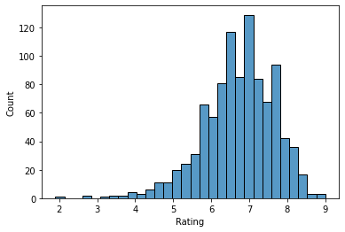

```
Metascore-Count histogram seems symmetric, looks like Rating-Count.
```

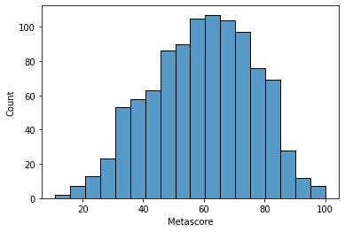

```
Runtime-Count histogram is right-skewed. Most of the movies are 90-120 minutes. There are only few films over 3 hours or less than 80 minutes
```

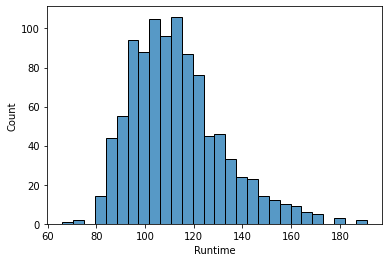

[output not shown]

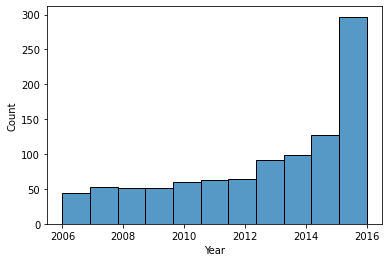

```
Revenue-Count histogram is right-skewed. We can see that the number of movies that have made huge profits is very few.
```

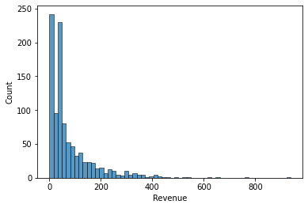

```
Votes-Count histogram is right skewed. The number of movies voted by large audiences is quite low.
```

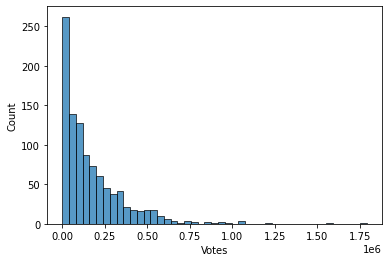

```python
print("4.a) Histogram")
copy=imdb.copy()
print("")
print("Rating-Count histogram is left-skewed. We can see that most of the movies have been rated between 6-8.")
sns.histplot(copy["Rating"])
plt.show()

print("Metascore-Count histogram seems symmetric, looks like Rating-Count.")
sns.histplot(copy["Metascore"])
plt.show()

print("Runtime-Count histogram is right-skewed. Most of the movies are 90-120 minutes. There are only few films over 3 hours or less than 80 minutes ")
sns.histplot(copy["Runtime"])
plt.show()

print("Year-Count histogram is left-skewed. In my dataset, film count increases every year.")
sns.histplot(copy["Year"])
plt.show()

print("Revenue-Count histogram is right-skewed. We can see that the number of movies that have made huge profits is very few.")
sns.histplot(copy["Revenue"])
plt.show()

print("Votes-Count histogram is right skewed. The number of movies voted by large audiences is quite low.")
sns.histplot(copy["Votes"])
plt.show()
```

```
4.b) Scatter Plot

Rating-Revenue -> Exponential positive correlation. It can be said with certainty that a low-rated film earned little revenue.
```

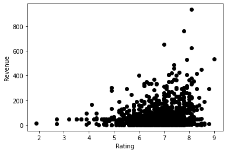

```python
print("4.b) Scatter Plot")
print("")

print("Rating-Revenue -> Exponential positive correlation. It can be said with certainty that a low-rated film earned little revenue.")
plt.plot(copy["Rating"],copy["Revenue"], 'o', color='black');
plt.xlabel("Rating");
plt.ylabel("Revenue");
```

```
Rating-Metascore -> Positive correlation. But also there are outliers.
These outliers mean film-critics and standard-audiences have opposite opinions about some films.
```

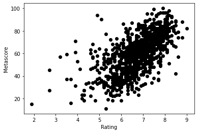

```python
print("Rating-Metascore -> Positive correlation. But also there are outliers.")
print("These outliers mean film-critics and standard-audiences have opposite opinions about some films.")
plt.plot(copy["Rating"],copy["Metascore"], 'o', color='black');
plt.xlabel("Rating")
plt.ylabel("Metascore");
```

```
Rating-Votes -> Exponential positive correlation.
Its certain that; number of votes of a low-rated-movie is low.
And the movie with a high rating is likely to have a large number of votes.
```

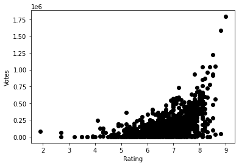

```python
print("Rating-Votes -> Exponential positive correlation.")
print("Its certain that; number of votes of a low-rated-movie is low.")
print("And the movie with a high rating is likely to have a large number of votes.")
plt.plot(copy["Rating"],copy["Votes"], 'o', color='black');
plt.xlabel("Rating")
plt.ylabel("Votes");
```

```
Year-Revenue -> No correlation.
```

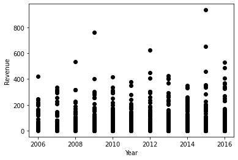

```python
print("Year-Revenue -> No correlation.")
plt.plot(copy["Year"],copy["Revenue"], 'o', color='black');
plt.xlabel("Year")
plt.ylabel("Revenue");
```